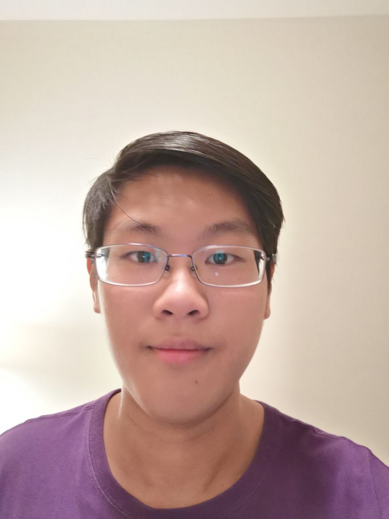

# Juncheng (Vincent) Liu

## Bio

Vincent is a first-year MS-Computational Analysis and Public Policy (MS-CAPP) student at the University of Chicago with demonstrated interests in criminal justice policy, k12 education, survey analysis, data visualizations, and machine learning. Since undergrad, he has been believing the power of minority and activated for social and criminal justice. He dreams for the day where social science reins the research and practice of public policies. He is also a dedicated and incurable heavy metal and hard rock lover. His favorite band of all time is Metallica because the band’s songs always give him power and energies. He loves saying “Life without energy can not be called life.”.

## Education

**University of Chicago** | Chicago, IL

M.S. in Computational Analysis and Public Policy | September 2021 - June 2023

**The University of Minnesota, Twin Cities** | Twin Cities, MN

B.S. in Sociology of Law, Criminology, and Deviance | September 2017 - May 2021

B.A. in Statistics | September 2017 - May 2021

Minor in Political Science | September 2017 - May 2021

DirecTrack to Teaching | September 2017 - May 2021

## Experience

**Smart Decarceration Project at Crown School of Social Works** | Research Assistant | January 2022 - now

**Department of Computational Social Science at U Chicago** | Workshop Facilitator | September 2021 - now

**Breakthrough Twin Cities** | Teaching Fellow | June 2020 - August 2020

**Juvenile Supervision Center** | Intern | September 2019 - March 2020

**Innocent Technologies** | Program and Evaluations Intern | June 2019 - August 2019